# Tutorial on R and R Studio (Part I)

Le Wang

## Roadmap

1. Why do we need computer programs?
2. What is `R`?
3. Why `R`? Three useful features
4. Why R studio?
5. A Short Tour of R Studio
6. Script file

## Why do we need computer programs?

Let’s look at a dataset. see if you can discern any pattern

```
##  [1] 69 29 47 10  6 43 32 45 51 21 48 84 72 56 22  1 90 49 30 77  9 38 20
## [24] 70 71 66 80 36 60 35 23 32 95 65  5 87  7  7 56 29 92 66 61 54 66 77
## [47] 32  1 55 18
```

Imagine that you have millions or even billions of these numbers and more dimensions.

## Why do we need computer programs?

To emphasize the important role that quantitative social science research can play in today’s data-rich society. To make contributions to this society through data-driven discovery, we must learn how to analyze data, interpret the resulting empirical evidence, and communicate our findings to others.

To start our journey, we presented a brief introduction to `R`, which is a powerful programming language for data analysis.

## What is `R`?

`R` is a **programming language** used for statistical analysis and graphics. It is based on S-plus, which itself was based on S, a programming language originally developed by AT&T.

If you are interested in the history (and future) of `R`, please refer to an article **R : Past and Future History** by Ross Ihaka.

## Why `R`?

Three useful features:

1. Object-Oriented Programming
2. Polymorphic
3. Functional Programming

## `R`: Object-Oriented Programming

Unlike many other statistical softwares such as SAS and SPSS, `R` will not spit out a mountain of output on the screen.

Instead, `R` returns an **object** containing all the results. You, as an user, have the flexibility to choose which result to be extracted or reported.

## `R`: Polymorphic

`R` is also *polymorphic*, which means that a single function can be applied to different types of inputs (much more user friendly).

Such a function is called a *generic function* (If you are a C++ programmer, you have seen a similar concept in *virtual functions*).

## `R`: Polymorphic (Example)

Lets look at one example `plot()`

1. Plot a vector of numbers
2. Plot some model results

No matter which purpose, we use the same function.

## `R`: Polymorphic (Example)

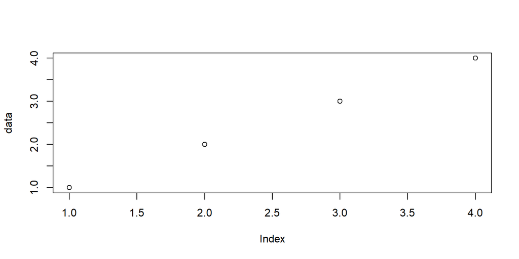

```r
data<-c(1,2,3,4)
plot(data)
```

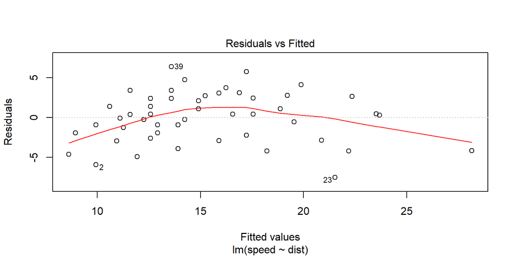

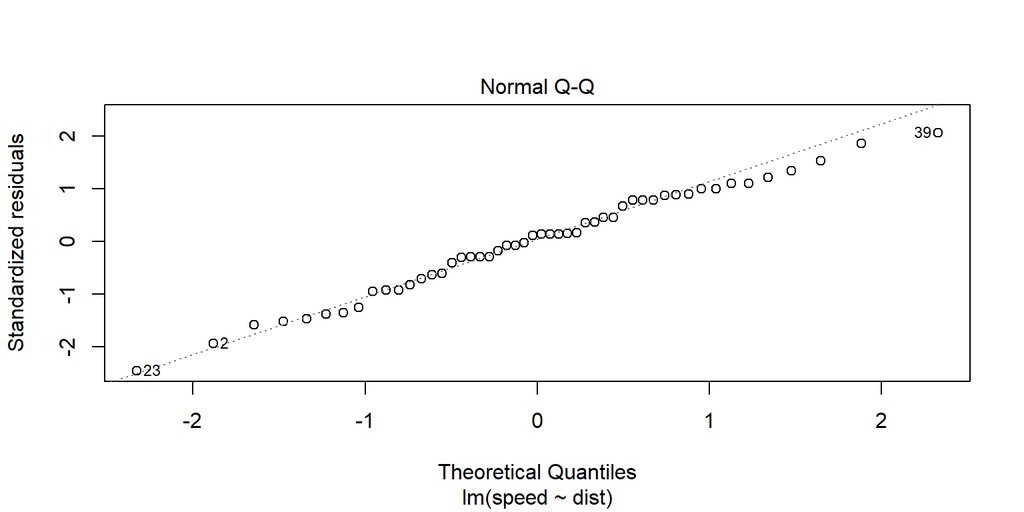

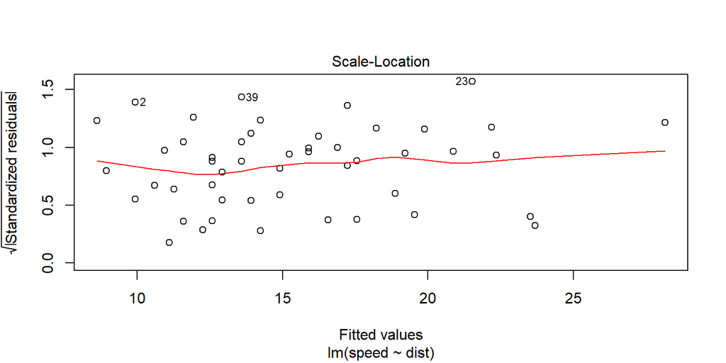

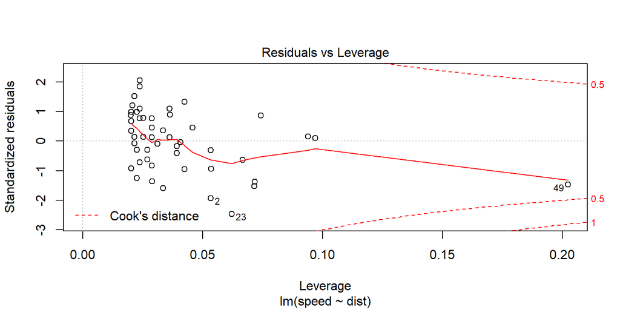

```r
# Regression Analysis
results<-lm(speed ~ dist,data=cars)
plot(results)
```

## `R`: Functional Programming

This feature allows us to write faster yet more compact code. For example, a common theme in `R` programming is **avoidance of explicit iteration**. Unlike many other statistical softwares, explicit loops are discouraged.

Instead, `R` provides some functions that could allow us to express iterative behavior implicitly.

## Why R Studio?

`R` Interface is **ugly**!

Many students in this class are much more familiar with Windows operation system and have never been exposed programming before, so we will use R studio, one of the free GUIs that have been developed for `R`.

R studio should really be considered as *integrated development environments* (IDEs), since it is aimed more toward programming.

## R Studio: A short tour

**Initial Start**

When you first (like very first time) open R studio you will see three panels.

[figure not shown]

## R Studio: A short tour

**Console**

[figure not shown]

**Console**

1. Everytime you launch RStudio, it will have the same text at the top of the console telling you the version of R that you’re running.
2. Below that information is the prompt, > . As its name suggests, this prompt is really a request, a request for a command.
3. Initially, interacting with R is all about typing commands and interpreting the output.
4. These commands and their syntax have evolved over decades (literally) and now provide what many users feel is a fairly natural way to access data and organize, describe, and invoke statistical computations.

The console is where you type commands and have them immediately performed.

## R Studio: A short tour

**Environment** The panel in the upper right contains your workspace (aka Environment)

[figure not shown]

## R Studio: A short tour

**History** Up here there is an additional tab to see the history of the commands that you’ve previously entered.

[figure not shown]

## R Studio: A short tour

**Files** The files tab allows you to open code/script files within R studio.

[figure not shown]

## R Studio: A short tour

**Plots** Any plots that you generate will show up in the panel in the lower right corner.

[figure not shown]

## R Studio: A short tour

**Help** To check the syntax of any function in R, type ? in front of the function name to pull up the help file.

[figure not shown]

For example here I typed ?mean to get the help file for the mean function. Admittedly these aren’t the most helpful of files at times.

## R Studio: A short tour

**Script File** The top left is your editor window, where you write code or script, the console is now at the bottom.**I usually change it**

[figure not shown]

## R Script

Most of `R` users typically submit commands to `R` by typing either in console or editor panel, rather than clicking a mouse in a Graphical User Interface (GUI).

**Script** is nothing but **a collection of commands**

## R Script and Reproducible Research

There are at least two advantages of doing so.

1. This allows us to run a bunch of results altogether by putting a collection of commands in a file (i.e., “script”“).
2. It is also a lot more transparent and straightforward to replicate what you have done.

**In our class, you will do this!**

## R Script

**Quiz 1:** Create a script file